# Diabetes

#### Discrimination

There is generally a trade off between a model’s sensitivity (ability to identify the true positives) and specificity (ability to identify the true negatives). The values reported above correspond to one specific cutoff for the predictions. To describe the discriminative ability of the model over different possible cutoffs, we can resort to the receiver operating characteristic (ROC) plot, where sensitivity is plotted against specificity for different cutoff values. The area under the ROC curve (AUC) is a popular indicator of how well the model performs with regards to discrimination.

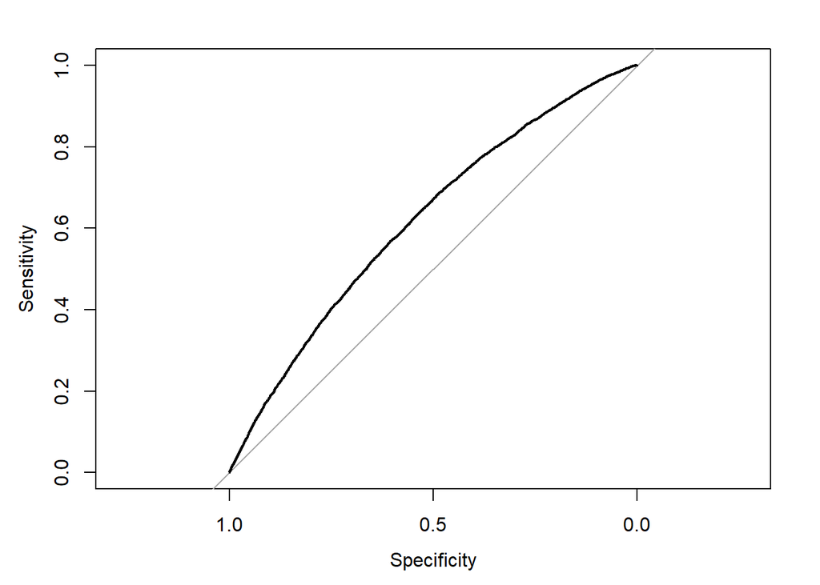

```r
roc <- roc(data$readmitted, pred,
            # arguments for ci
            ci=TRUE, plot = TRUE, auc = TRUE)
```

```r
roc
```

```
##
## Call:
## roc.default(response = data$readmitted, predictor = pred, auc = TRUE,     ci = TRUE, plot = TRUE)
##
## Data: pred in 63696 controls (data$readmitted NO) < 6277 cases (data$readmitted YES).
## Area under the curve: 0.6189
## 95% CI: 0.6117-0.626 (DeLong)
```

#### Calibration

```r
cal = val.prob(pred, ifelse(data$readmitted == "NO", 0,1), logistic.cal = FALSE, lim = c(0,0.4))
```

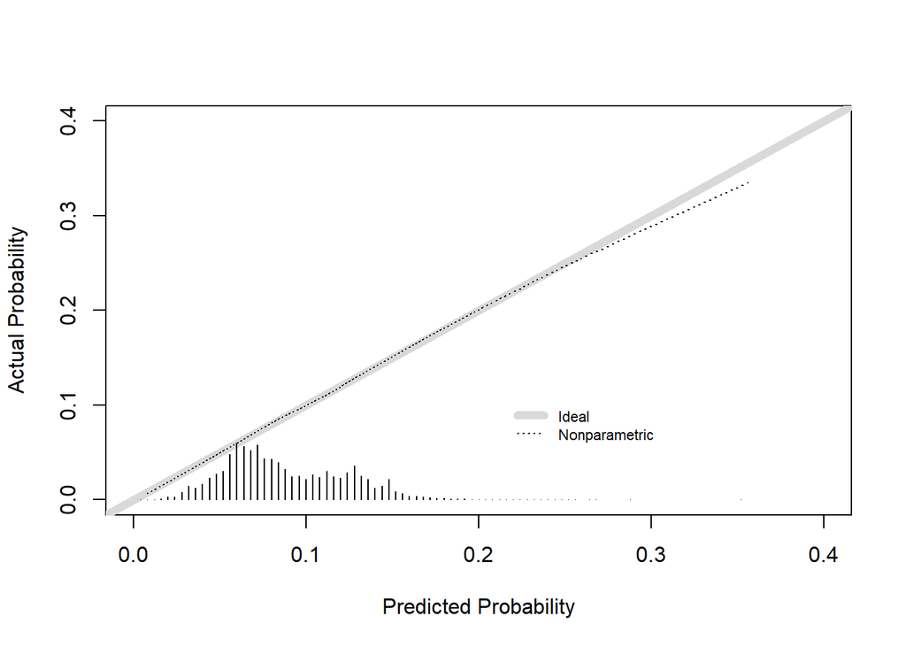

```r
cal[c("Intercept", "Slope")]
```

```
##    Intercept        Slope
## 4.190593e-10 1.000000e+00
```

### Validation

Previously, we considered measures of performance using the whole dataset, and predictions of the same observations that were used to build the model. For a more realistic assessment of the model’s performance, the model should be validated, and there are a couple of options: split-sample validation and K-fold cross-validation (CV).

#### Split-sample

We can divide the data into two parts: the training set (80%) and the validation set (20%). This is split smaple validation.

```r
set.seed(123)
indices = sample(1:nrow(data), size = round(nrow(data)/5))
data_val = data[indices, ]
data_train = data[-indices, ]
```

Pseudo $R^2$ with split-sample:

```r
fitnull_split = glm(readmitted ~ 1, family = "binomial", data = data_train)
prednull_split <- predict(fitnull_split, data_val, type = "response")
brierScore_null <- mean((prednull_split - ifelse(data_val$readmitted == "NO", 0 , 1))^2)

fit_split = glm(readmitted ~ discharge + race + source + medical_specialty + time_in_hospital + age + diag_1 + A1Cresult  +  diag_1 * discharge + race * discharge + medical_specialty*discharge + discharge*time_in_hospital + time_in_hospital*medical_specialty + age * medical_specialty + time_in_hospital*diag_1 + A1Cresult* diag_1, family = "binomial", data = data_train)
pred_split <- predict(fit_split, data_val, type='response')
brierScore <- mean((pred_split - ifelse(data_val$readmitted == "NO", 0 , 1))^2)

print(c(brierScore, brierScore_null))
```

```
## [1] 0.08052006 0.08151605
```

Nagelkerke’s $R^2$ with split-sample:

```r
fit_rms = lrm(readmitted ~ discharge + race + source + medical_specialty + time_in_hospital + age + diag_1 + A1Cresult  +  diag_1 * discharge + race * discharge + medical_specialty*discharge + discharge*time_in_hospital + time_in_hospital*medical_specialty + age * medical_specialty + time_in_hospital*diag_1 + A1Cresult* diag_1, data = data_train, x = TRUE, y = TRUE)
fit_rms$stats["R2"]
```

```
##         R2
## 0.03162029
```

ROC

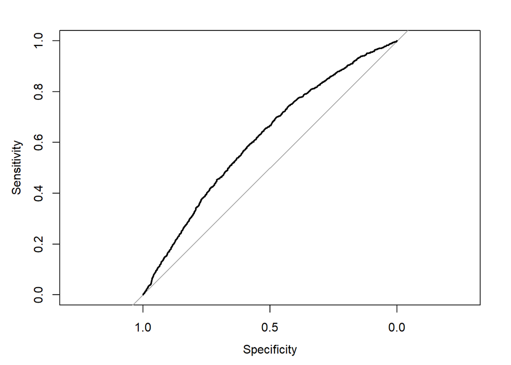

```r
roc_split <- roc(data_val$readmitted, pred_split,
            # arguments for ci
            ci=TRUE, plot = TRUE, auc = TRUE)
```

```r
roc_split
```

```
##
## Call:
## roc.default(response = data_val$readmitted, predictor = pred_split,     auc = TRUE, ci = TRUE, plot = TRUE)
##
## Data: pred_split in 12742 controls (data_val$readmitted NO) < 1253 cases (data_val$readmitted YES).
## Area under the curve: 0.6148
## 95% CI: 0.599-0.6307 (DeLong)
```

Calibration plot

```r
cal_split = val.prob(pred_split, ifelse(data_val$readmitted == "NO", 0,1), logistic.cal = FALSE, lim = c(0,0.4))
```

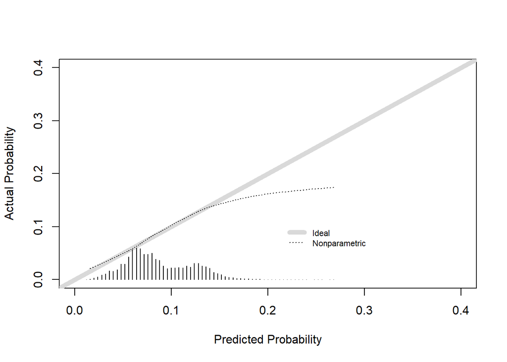

```r
cal_split[c("Intercept", "Slope")]
```

```
##  Intercept      Slope
## -0.1582640  0.9303273
```

#### Cross-validation

ROC

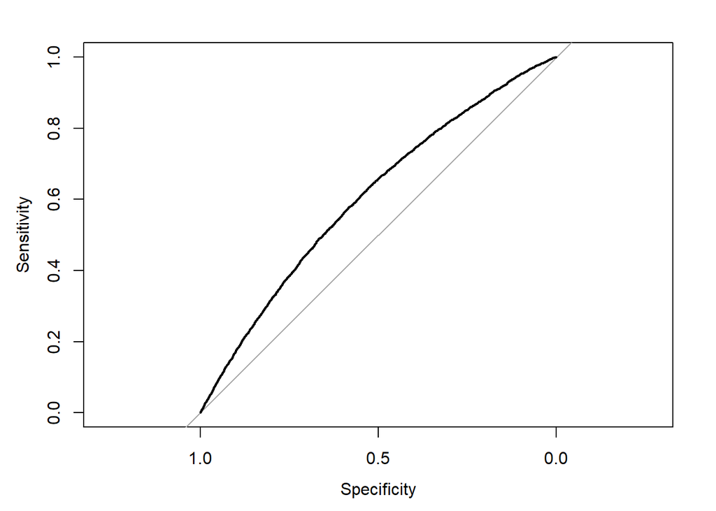

```r
roc_CV <- roc(fit_CV$pred$obs, fit_CV$pred$YES,
            # arguments for ci
            ci=TRUE, plot = TRUE, auc = TRUE)
```

```r
roc_CV
```

```
##
## Call:
## roc.default(response = fit_CV$pred$obs, predictor = fit_CV$pred$YES,     auc = TRUE, ci = TRUE, plot = TRUE)
##
## Data: fit_CV$pred$YES in 50954 controls (fit_CV$pred$obs NO) < 5024 cases (fit_CV$pred$obs YES).
## Area under the curve: 0.606
## 95% CI: 0.598-0.6141 (DeLong)
```

```r
cal_CV = val.prob(fit_CV$pred$YES, ifelse(fit_CV$pred$obs == "NO", 0,1), logistic.cal = FALSE, lim = c(0,0.4))
```

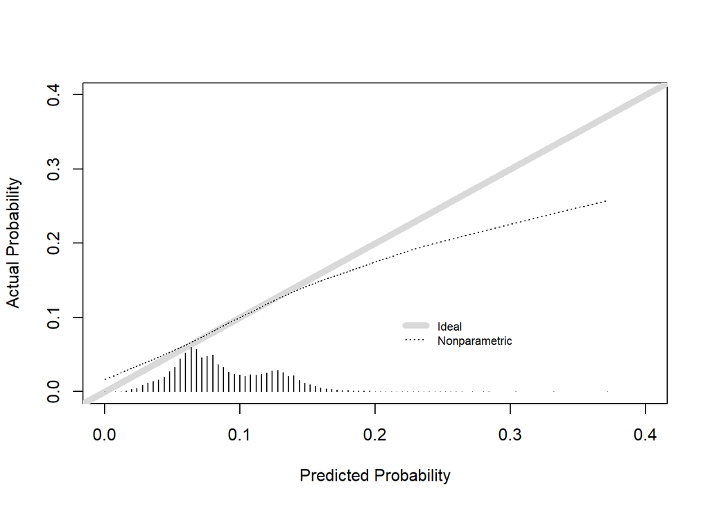

```r
cal_CV[c("Intercept", "Slope")]
```

```
##  Intercept      Slope
## -0.3578430  0.8413221
```

[output not shown]

### Decision Trees

In addition to regression methods, the data can be explored with decision trees.

The following metrics are based on a single tree:

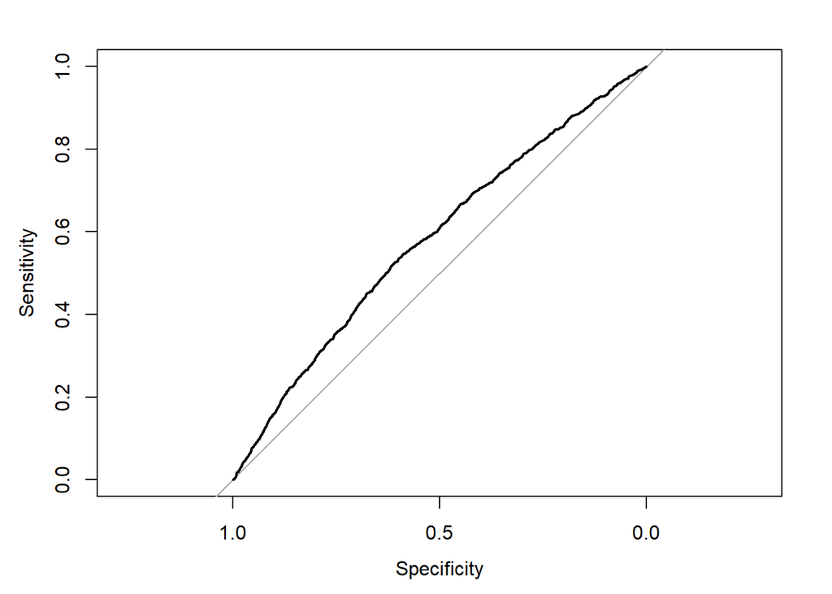

```r
tree_rpart = rpart(readmitted ~ discharge + race + source + medical_specialty + time_in_hospital + age + diag_1 + A1Cresult, data = data_train, minsplit = 200, cp=-1)
pred_tree = predict(tree_rpart, newdata = data_val)

roc_tree <- roc(data_val$readmitted, pred_tree[, 2],
            # arguments for ci
            ci=TRUE, plot = TRUE, auc = TRUE)
```

```r
roc_tree
```

```
##
## Call:
## roc.default(response = data_val$readmitted, predictor = pred_tree[,     2], auc = TRUE, ci = TRUE, plot = TRUE)
##
## Data: pred_tree[, 2] in 12742 controls (data_val$readmitted NO) < 1253 cases (data_val$readmitted YES).
## Area under the curve: 0.5803
## 95% CI: 0.5636-0.597 (DeLong)
```

```r
cal_tree = val.prob(pred_tree[,2], ifelse(data_val$readmitted == "NO", 0,1), logistic.cal = FALSE, lim = c(0,0.4))
```

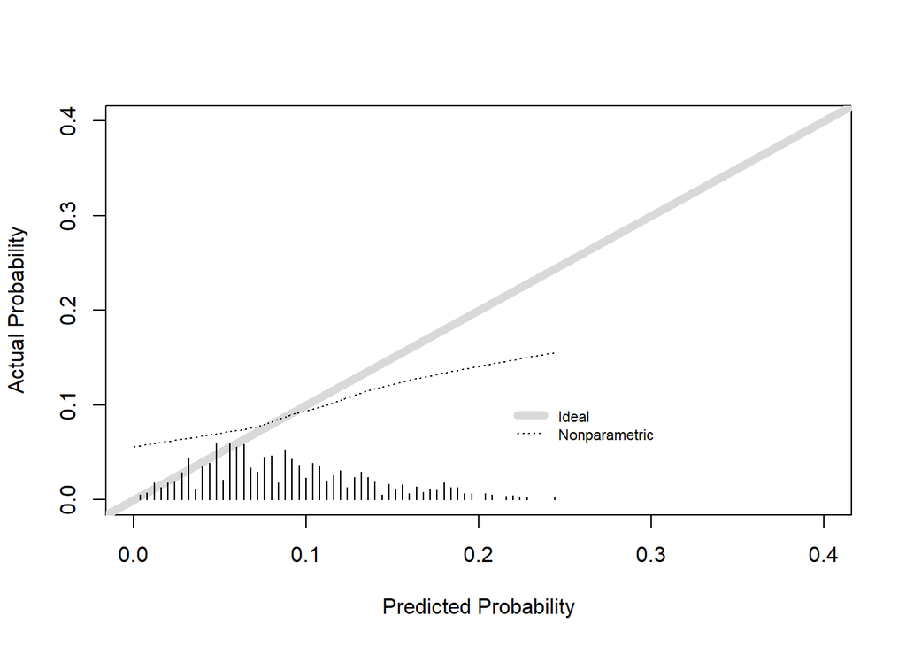

```r
cal_tree[c("Intercept", "Slope")]
```

```
##  Intercept      Slope
## -1.2984419  0.4253446
```

Variable importance: discharge, time in hospital and diagnosis are the three most important variables with a single classification tree, although discharge was not statistically significant in the logistic regression model.

```r
tree_rpart$variable.importance
```

```
##         discharge            diag_1  time_in_hospital medical_specialty
##          80.64430          57.12041          52.99112          37.24036
##            source              race               age         A1Cresult
##          19.55801          16.06836          12.87671          11.86181
```

Bagging

```r
set.seed(123)
tree_bagg <- train(readmitted ~ discharge + race + source + medical_specialty + time_in_hospital + age + diag_1 + A1Cresult, data = data,
                 method = "bag",
                 trControl = trCntl, bagControl = bagControl(fit = ldaBag$fit, predict = ldaBag$pred, aggregate = ldaBag$aggregate))
```

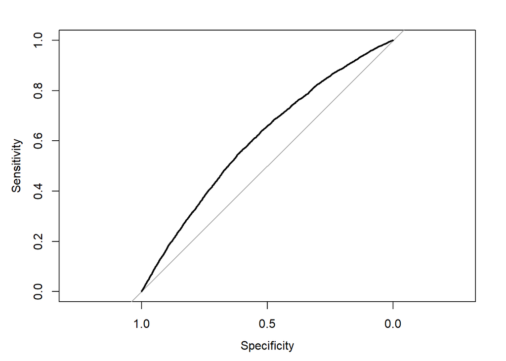

```r
roc_bagg <- roc(tree_bagg$pred$obs, tree_bagg$pred$YES,
            # arguments for ci
            ci=TRUE, plot = TRUE, auc = TRUE)
```

```r
roc_bagg
```

```
##
## Call:
## roc.default(response = tree_bagg$pred$obs, predictor = tree_bagg$pred$YES,     auc = TRUE, ci = TRUE, plot = TRUE)
##
## Data: tree_bagg$pred$YES in 63696 controls (tree_bagg$pred$obs NO) < 6277 cases (tree_bagg$pred$obs YES).
## Area under the curve: 0.6066
## 95% CI: 0.5994-0.6137 (DeLong)
```

```r
cal_bagg = val.prob(tree_bagg$pred$YES, ifelse(tree_bagg$pred$obs == "NO", 0,1), logistic.cal = FALSE, lim = c(0,0.4))
```

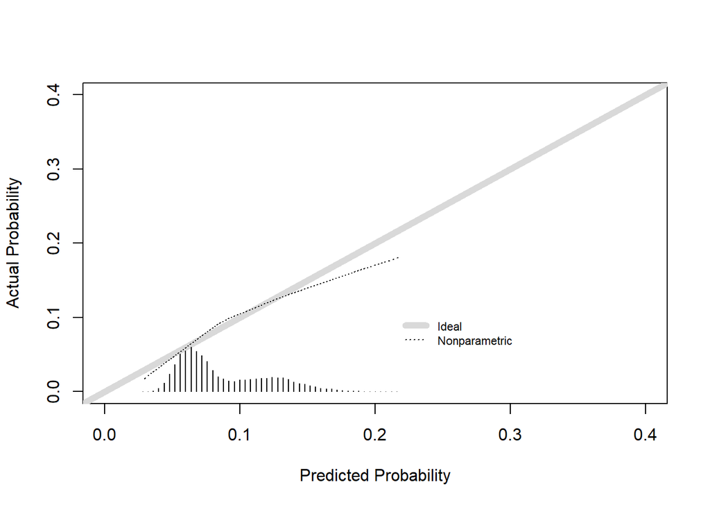

```r
cal_bagg[c("Intercept", "Slope")]
```

```
##  Intercept      Slope
## -0.1441192  0.9344920
```

```r
varImp(tree_bagg)
```

```
## ROC curve variable importance
##
##                   Importance
## discharge            100.000
## time_in_hospital      74.523
## age                   44.357
## medical_specialty      5.584
## source                 5.301
## race                   4.463
## A1Cresult              1.175
## diag_1                 0.000
```

Random Forest

```r
# convert from data.frame to a sparse matrix
temp <- data.table(data[ ,c("discharge","race", "source", "medical_specialty", "time_in_hospital", "age", "diag_1", "A1Cresult")])  # convert x to a data.table
data_sparse <- sparsify(temp)
data_dmat <- xgb.DMatrix(data = data_sparse, label = ifelse(data$readmitted == "NO", 0, 1))

# set parameters for xgboost
params = list(colsample_bynode = floor(sqrt(8))/8,
  eta= 1,
  max_depth = 100,
  subsample = 1,
  num_parallel_tree = 200,
  objective='binary:logistic',
  reg_lambda=0.01,
  min_child_weight=0.01
)

# xgboost for faster random forest
set.seed(123)
tree_rf = xgb.cv(params = params, nfold = 10, data = data_dmat, nrounds = 1, prediction = TRUE)
```

[output not shown]

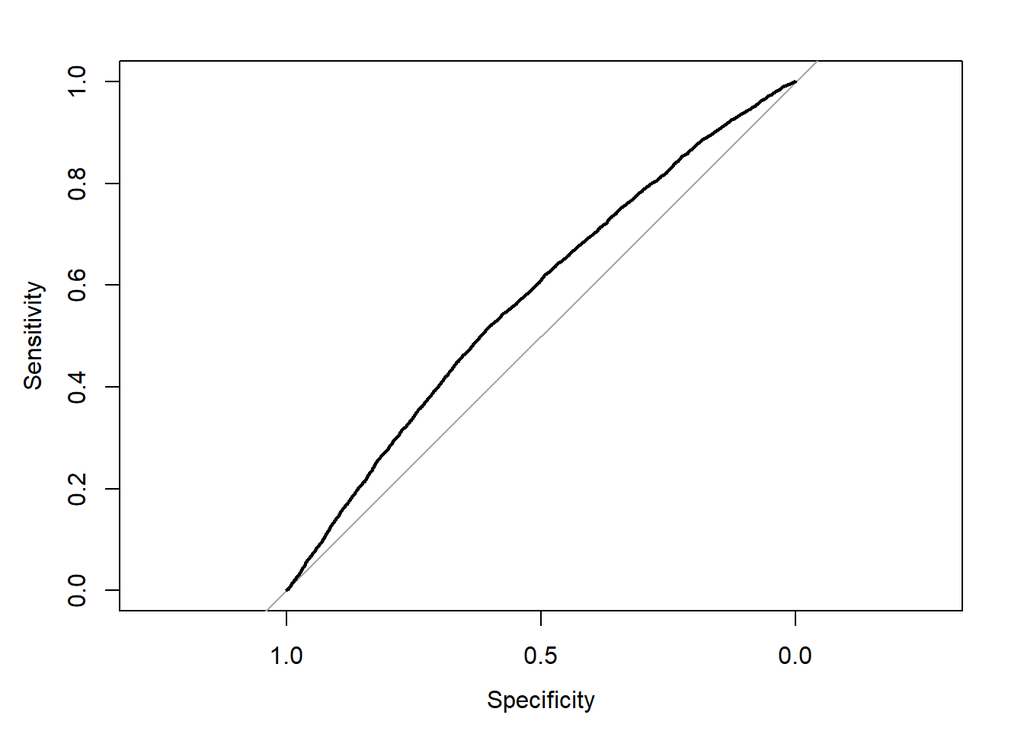

```r
roc_rf <- roc(data$readmitted, tree_rf$pred,
            # arguments for ci
            ci=TRUE, plot = TRUE, auc = TRUE)
```

```r
roc_rf
```

```
##
## Call:
## roc.default(response = data$readmitted, predictor = tree_rf$pred,     auc = TRUE, ci = TRUE, plot = TRUE)
##
## Data: tree_rf$pred in 63696 controls (data$readmitted NO) < 6277 cases (data$readmitted YES).
## Area under the curve: 0.5759
## 95% CI: 0.5685-0.5832 (DeLong)
```

```r
cal_rf = val.prob(tree_rf$pred, ifelse(data$readmitted == "NO", 0,1), logistic.cal = FALSE, lim = c(0,0.4))
```

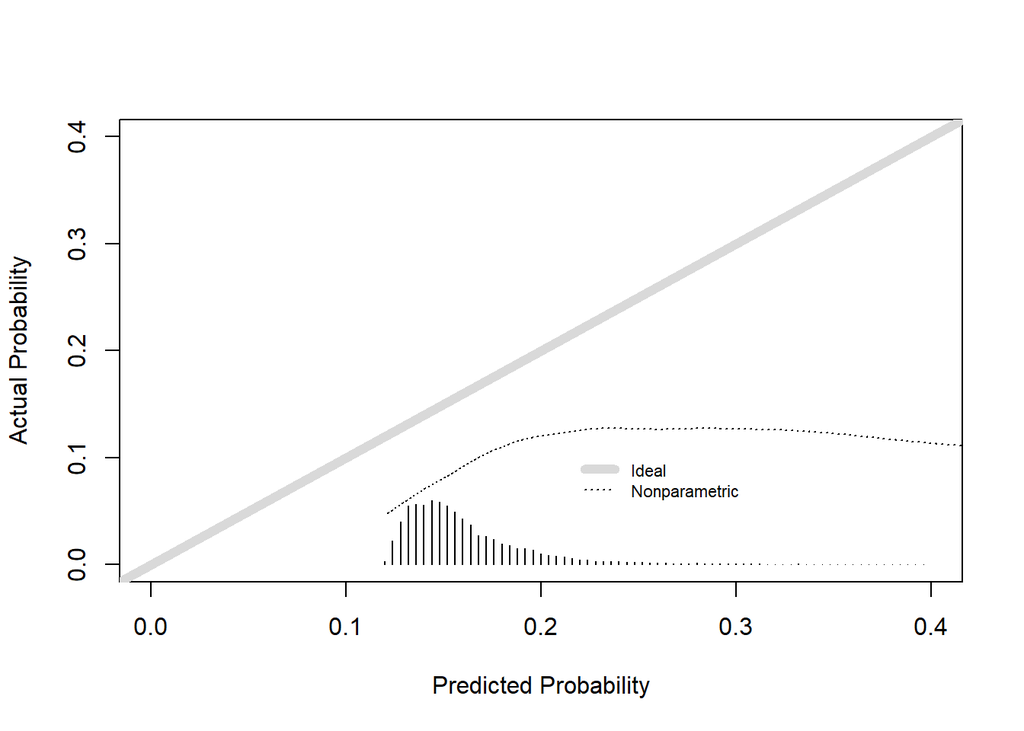

```r
cal_rf[c("Intercept", "Slope")]
```

```
##  Intercept      Slope
## -1.2713767  0.6479677
```

```r
test=xgboost(data = data_dmat,params = params, nrounds = 1 )
```

```
## [01:59:45] WARNING: amalgamation/../src/learner.cc:1095: Starting in XGBoost 1.3.0, the default evaluation metric used with the objective 'binary:logistic' was changed from 'error' to 'logloss'. Explicitly set eval_metric if you'd like to restore the old behavior.
```

```r
xgb.importance(model = test)[1:10,]
```

```
##                                  Feature       Gain      Cover   Frequency
##  1:                     time_in_hospital 0.22799755 0.14289381 0.178918103
##  2:                       discharge_Home 0.03978497 0.04064001 0.001932977
##  3:                       race_Caucasian 0.03818638 0.03242388 0.049771537
##  4:                race_African American 0.03751905 0.02066423 0.047244720
##  5:                       A1Cresult_None 0.03723921 0.03071333 0.050686289
##  6: medical_specialty_Missing or Unknown 0.03408438 0.02947584 0.042096613
##  7:                     source_Emergency 0.03280931 0.03358666 0.039238386
##  8:                     A1Cresult_Normal 0.03011352 0.01915683 0.037434374
##  9:   medical_specialty_InternalMedicine 0.03007038 0.03290327 0.032572689
## 10:                         diag_1_Other 0.02918557 0.02377103 0.032404735
```

Boosting

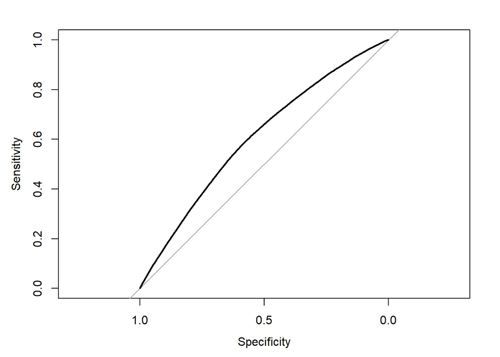

```r
set.seed(123)
tree_boost <- train(readmitted ~ discharge + race + source + medical_specialty + time_in_hospital + age + diag_1 + A1Cresult, data = data,
                 method = "gbm",
                 trControl = trCntl,
                 verbose = FALSE)

roc_boost <- roc(tree_boost$pred$obs, tree_boost$pred$YES,
            # arguments for ci
            ci=TRUE, plot = TRUE, auc = TRUE)
```

```r
roc_boost
```

```
##
## Call:
## roc.default(response = tree_boost$pred$obs, predictor = tree_boost$pred$YES,     auc = TRUE, ci = TRUE, plot = TRUE)
##
## Data: tree_boost$pred$YES in 573264 controls (tree_boost$pred$obs NO) < 56493 cases (tree_boost$pred$obs YES).
## Area under the curve: 0.6067
## 95% CI: 0.6043-0.6091 (DeLong)
```

```r
cal_boost = val.prob(tree_boost$pred$YES, ifelse(tree_boost$pred$obs == "NO", 0,1), logistic.cal = FALSE, lim = c(0,0.4))
```

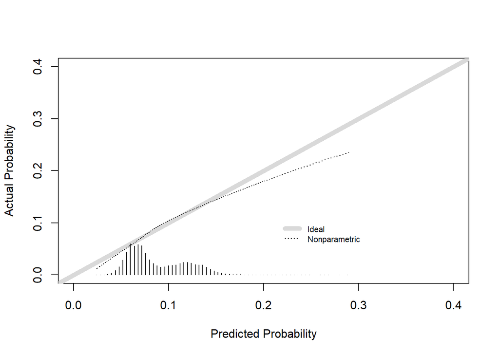

```r
cal_boost[c("Intercept", "Slope")]
```

```
##  Intercept      Slope
## 0.05317641 1.02345724
```

```r
varImp(tree_boost)
```

```
## gbm variable importance
##
##   only 20 most important variables shown (out of 25)
##
##                                      Overall
## dischargeOther                      100.0000
## time_in_hospital                     23.3670
## age[60, 100)                         11.0306
## diag_1Respiratory                     3.6349
## medical_specialtyInternalMedicine     1.6959
## diag_1Circulatory                     1.3240
## diag_1Musculoskeletal                 1.3064
## medical_specialtyOther                1.2384
## A1CresultNormal                       0.5411
## diag_1Digestive                       0.0000
## medical_specialtyMissing or Unknown   0.0000
## diag_1Neoplasms                       0.0000
## raceMissing                           0.0000
## diag_1Injury and poisoning            0.0000
## raceOther                             0.0000
## sourceReferral                        0.0000
## A1Cresulthigh_ch                      0.0000
## A1Cresulthigh_noch                    0.0000
## sourceOther                           0.0000
## diag_1Other                           0.0000
```

The following table compares logistic regression to different tree-based methods. Bagging and boosting but not random forest had similar performance compared to logistic regression.

[output not shown]

[1] Beata Strack, Jonathan P. DeShazo, Chris Gennings, Juan L. Olmo, Sebastian Ventura, Krzysztof J. Cios, John N. Clore, “Impact of HbA1c Measurement on Hospital Readmission Rates: Analysis of 70,000 Clinical Database Patient Records”, BioMed Research International, vol. 2014, Article ID 781670, 11 pages, 2014. https://doi.org/10.1155/2014/781670